# ICE Arrests: Illinois Since January 20, 2025

Detention itineraries, transfer flows, and removal outcomes

Published

October 14, 2026

This report traces ICE arrests made in **Illinois** on or after **January 20, 2025** through the full detention and removal pipeline, using individual-level FOIA data from the [Deportation Data Project](https://deportationdata.org).

**6,279** arrests · **6,209** distinct individuals · **5,853** detention stays · **68.1%** ultimately removed

## Overview

### Monthly arrest volume

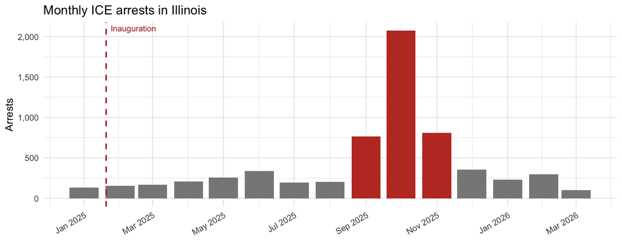

### Who was arrested

**Top nationalities**

| Country | N | % |
| --- | --- | --- |
| MEXICO | 2622 | 41.8 |
| VENEZUELA | 972 | 15.5 |
| GUATEMALA | 450 | 7.2 |
| COLOMBIA | 445 | 7.1 |
| ECUADOR | 382 | 6.1 |
| HONDURAS | 230 | 3.7 |
| NICARAGUA | 220 | 3.5 |
| INDIA | 88 | 1.4 |
| EL SALVADOR | 84 | 1.3 |
| RUSSIA | 69 | 1.1 |
| KYRGYZSTAN | 66 | 1.1 |
| POLAND | 61 | 1.0 |
| CHINA, PEOPLES REPUBLIC OF | 59 | 0.9 |
| PERU | 48 | 0.8 |
| JORDAN | 33 | 0.5 |

**Arrest type**

| Arrest type | N | % |
| --- | --- | --- |
| Targeted | 2752 | 43.8 |
| Collateral | 2052 | 32.7 |
| NA | 1475 | 23.5 |

**Criminality at arrest**

| Criminality | N | % |
| --- | --- | --- |
| 3 Other Immigration Violator | 3413 | 54.4 |
| 1 Convicted Criminal | 1508 | 24.0 |
| 2 Pending Criminal Charges | 1358 | 21.6 |

## Arrest Locations in Illinois

County-level map based on `apprehension_site_landmark`. Landmarks naming a county in the state, or a place with a known county (prisons, field offices, airports), are mapped. Field-office-wide landmarks (e.g. “CHI GENERAL AREA, NON-SPECIFIC”) cover several states and can’t be placed in a county; they are summarized alongside the map.

[interactive chart not shown]

Share of arrests shown on the map

| Arrest location | N | % of arrests |
| --- | --- | --- |
| Mapped to a county | 636 | 10.1 |
| Field office area, non-specific | 5078 | 80.9 |
| Fugitive operations, no county | 525 | 8.4 |
| Other / unresolved | 23 | 0.4 |
| Located in another state | 15 | 0.2 |
| Missing landmark | 2 | 0.0 |

Largest unmapped landmarks

| Unmapped landmark | N | % |
| --- | --- | --- |
| Chi General Area, Non-Specific | 4864 | 77.5 |
| Chifugitive Operations | 513 | 8.2 |
| Stl General Non-Specific | 87 | 1.4 |
| Rii General Area, Non-Specific | 31 | 0.5 |
| Bsa General Area, Non-Specific | 18 | 0.3 |
| Epc General Area, Non-Specific | 17 | 0.3 |
| St Louis Ice Office | 10 | 0.2 |
| Xoh General Area, Non-Specific | 9 | 0.1 |

> **Coverage:** 10% of arrests mapped to a county. The map shows only these arrests; the tables at right show what is left out.

## Detention Facility Maps and Transfer Flows

**Blue dots** = first detention facility. **Orange dots** = last detention facility. **Grey lines** = transfer flows between facilities; line width is proportional to the log of the number of transfers on that route. Only flows with ≥ 5 transfers are shown.

[interactive chart not shown]

**First detention facility (top 8):**

| DETLOC | Facility | City | State | N | % |
| --- | --- | --- | --- | --- | --- |
| BSAHOLD | Broadview Service Staging | Broadview | IL | 4886 | 83.5 |
| RIIHOLD | Rock Island Hold Room | Rock Island | IL | 288 | 4.9 |
| CHIHOLD | Chicago Field Office | Chicago | IL | 283 | 4.8 |
| STLHOLD | St. Louis Holdroom | St. Louis | MO | 240 | 4.1 |
| EROFCB | Camp East Montana | El Paso | TX | 16 | 0.3 |
| INPHOLD | Indianapolis Hold Room | Indianapolis | IN | 15 | 0.3 |
| MILHOLD | Milwaukee Holdroom | Milwaukee | WI | 12 | 0.2 |
| FSF | Florence Staging Facility | Florence | AZ | 10 | 0.2 |

**Last detention facility (top 10):**

| DETLOC | Facility | City | State | N | % |
| --- | --- | --- | --- | --- | --- |
| EROFCB | Camp East Montana | El Paso | TX | 837 | 14.3 |
| JENATLA | Alexandria Staging Facility | Alexandria | LA | 665 | 11.4 |
| BSAHOLD | Broadview Service Staging | Broadview | IL | 518 | 8.9 |
| NRLKCMI | North Lake Correctional Facility | Baldwin | MI | 471 | 8.0 |
| PIC | Port Isabel Detention Center | Los Fresnos | TX | 417 | 7.1 |
| PINEPLA | Pine Prairie ICE Processing Center | Pine Prairie | LA | 301 | 5.1 |
| CLAYCIN | Clay County Justice Center | Brazil | IN | 199 | 3.4 |
| ADAMSMS | Adams County Detention Center (Mississippi) | Natchez | MS | 197 | 3.4 |
| LAWINCI | Winn Correctional Center | Winnfield | LA | 137 | 2.3 |
| JKPCCLA | Jackson Parish Correctional Center | Jonesboro | LA | 130 | 2.2 |

## Removal Pipeline Flow

Each band traces one group through the pipeline: **Illinois arrest → first facility → last facility → outcome.** Band width is proportional to number of stays.

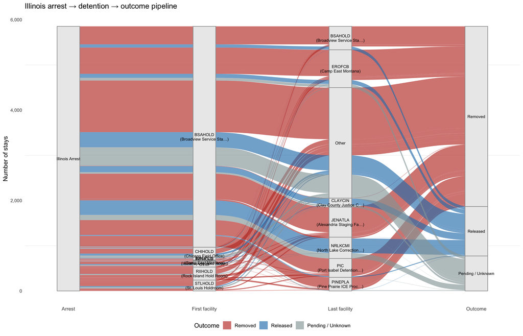

**Final outcomes:**

| Release reason | N | % |
| --- | --- | --- |
| Removed | 3985 | 68.1 |
| NA | 773 | 13.2 |
| Bonded Out - IJ | 498 | 8.5 |
| Order of recognizance | 186 | 3.2 |
| Paroled | 129 | 2.2 |
| U.S. Marshals or other agency (explain in Detention Comments) | 71 | 1.2 |
| Voluntary departure | 69 | 1.2 |
| Transferred | 37 | 0.6 |
| Order of supervision | 33 | 0.6 |
| Relief Granted by IJ | 25 | 0.4 |
| Proceedings Terminated | 17 | 0.3 |
| Order of Recognizance - Humanitarian | 10 | 0.2 |
| Bonded Out - Field Office | 8 | 0.1 |
| Court Ordered | 2 | 0.0 |
| ORR - Office of Refugee Resettlement | 2 | 0.0 |
| Paroled - Humanitarian | 2 | 0.0 |
| Died | 1 | 0.0 |
| Order of Supervision - Humanitarian | 1 | 0.0 |
| Order of Supervision - No SLRRFF | 1 | 0.0 |
| Order of Supervision - Re-Release | 1 | 0.0 |
| Voluntary Return | 1 | 0.0 |
| Withdrawal | 1 | 0.0 |

**All facilities in itineraries (top 15):**

| DETLOC | Appearances | % of stays |
| --- | --- | --- |
| BSAHOLD | 6069 | 103.7 |
| CLAYCIN | 1853 | 31.7 |
| INPHOLD | 1455 | 24.9 |
| EROFCB | 1263 | 21.6 |
| JENATLA | 988 | 16.9 |
| NRLKCMI | 808 | 13.8 |
| PIC | 768 | 13.1 |
| GREENMO | 614 | 10.5 |
| KANHOLD | 580 | 9.9 |
| PINEPLA | 427 | 7.3 |
| STLHOLD | 308 | 5.3 |
| RIIHOLD | 304 | 5.2 |
| CHIHOLD | 303 | 5.2 |
| ADAMSMS | 301 | 5.1 |
| STGENMO | 264 | 4.5 |

## Removal Destinations

The heatmap below crosses **citizenship country** (columns) against **country deported to** (rows). Cell numbers are absolute counts; cell color shows what share of that row’s removals came from each citizenship group. Top 15 destinations × top 12 citizenships shown.

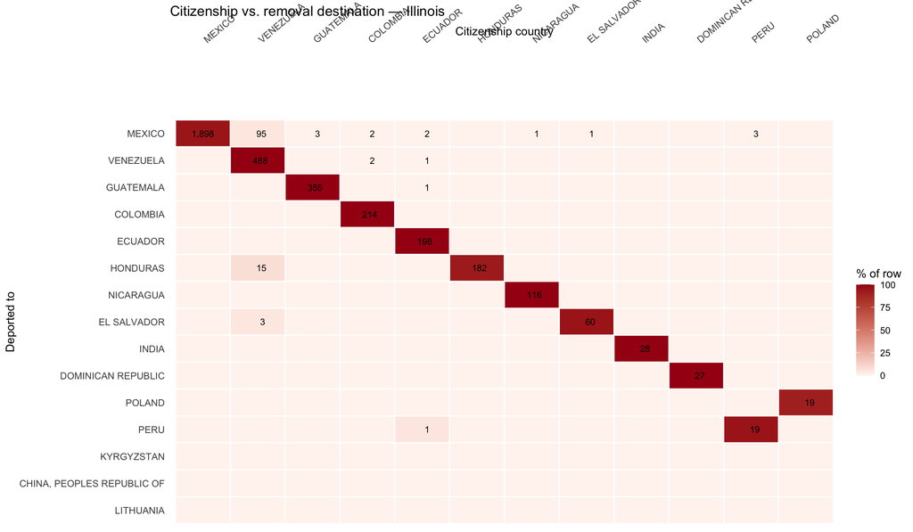

**Summary table:**

Removal destinations for Illinois arrests

| Country | N | % |
| --- | --- | --- |
| MEXICO | 2007 | 51.5 |
| VENEZUELA | 491 | 12.6 |
| GUATEMALA | 356 | 9.1 |
| COLOMBIA | 214 | 5.5 |
| ECUADOR | 198 | 5.1 |
| HONDURAS | 197 | 5.1 |
| NICARAGUA | 116 | 3.0 |
| EL SALVADOR | 63 | 1.6 |
| INDIA | 28 | 0.7 |
| DOMINICAN REPUBLIC | 27 | 0.7 |
| POLAND | 21 | 0.5 |
| PERU | 20 | 0.5 |
| KYRGYZSTAN | 17 | 0.4 |
| CHINA, PEOPLES REPUBLIC OF | 12 | 0.3 |
| LITHUANIA | 9 | 0.2 |
| NIGERIA | 7 | 0.2 |
| JORDAN | 6 | 0.2 |
| ROMANIA | 6 | 0.2 |
| COSTA RICA | 5 | 0.1 |
| PAKISTAN | 5 | 0.1 |

## Minor Detainees (Under 18)

**224 arrests** · **220 distinct individuals** · **80 detention stays.** Age is estimated as year(arrest) − birth year and may be off by up to one year.

| Metric | Value |
| --- | --- |
| Arrests of minors | 224 |
| Distinct minors | 220 |
| Detention stays | 80 |

**Age at arrest**

| Age | N |
| --- | --- |
| 2 | 1 |
| 3 | 5 |
| 4 | 12 |
| 5 | 19 |
| 6 | 18 |
| 7 | 14 |
| 8 | 22 |
| 9 | 12 |
| 10 | 10 |
| 11 | 13 |
| 12 | 23 |
| 13 | 17 |
| 14 | 11 |
| 15 | 13 |
| 16 | 15 |
| 17 | 19 |

**Nationality**

| Country | N | % |
| --- | --- | --- |
| COLOMBIA | 57 | 25.4 |
| ECUADOR | 47 | 21.0 |
| VENEZUELA | 43 | 19.2 |
| MEXICO | 18 | 8.0 |
| NICARAGUA | 12 | 5.4 |
| GUATEMALA | 9 | 4.0 |
| RUSSIA | 9 | 4.0 |
| HONDURAS | 6 | 2.7 |
| INDIA | 5 | 2.2 |
| PERU | 5 | 2.2 |
| EL SALVADOR | 4 | 1.8 |
| ROMANIA | 3 | 1.3 |
| JORDAN | 2 | 0.9 |
| PAKISTAN | 2 | 0.9 |
| KYRGYZSTAN | 1 | 0.4 |
| NIGERIA | 1 | 0.4 |

**First detention facility**

| DETLOC | Facility | N | % |
| --- | --- | --- | --- |
| CHIHOLD | CHICAGO HOLD ROOM | 68 | 85.0 |
| BSAHOLD | BROADVIEW SERVICE STAGING | 9 | 11.2 |
| BLOJVTN | BLOUNT COUNTY JUVENILE DET CNTR | 1 | 1.2 |
| SNDHOLD | SND DISTRICT STAGING | 1 | 1.2 |
| STFRCTX | SOUTH TEXAS FAM RESIDENTIAL CENTER | 1 | 1.2 |

**Last detention facility**

| DETLOC | Facility | N | % |
| --- | --- | --- | --- |
| CHIHOLD | CHICAGO HOLD ROOM | 45 | 56.2 |
| STFRCTX | SOUTH TEXAS FAM RESIDENTIAL CENTER | 33 | 41.2 |
| BLOJVTN | BLOUNT COUNTY JUVENILE DET CNTR | 1 | 1.2 |
| BSAHOLD | BROADVIEW SERVICE STAGING | 1 | 1.2 |

**Outcomes**

| Release reason | N | % |
| --- | --- | --- |
| Removed | 43 | 53.8 |
| Voluntary departure | 16 | 20.0 |
| Order of recognizance | 7 | 8.8 |
| NA | 7 | 8.8 |
| Paroled | 4 | 5.0 |
| ORR - Office of Refugee Resettlement | 2 | 2.5 |
| Order of Recognizance - Humanitarian | 1 | 1.2 |